# date: “May 14, 2017”

```r
knitr::opts_chunk$set(warning = FALSE, message = FALSE)
```

title: “Exploring Instacart Dataset with PCA” author: “Notesofdabbler”

## date: “May 14, 2017”

I wanted to explore the recently released [Instacart dataset](https://tech.instacart.com/3-million-instacart-orders-open-sourced-d40d29ead6f2) to see if I can explore patterns of the kind [shown in their blog](https://cdn-images-1.medium.com/max/800/1*wKfV6OV-_1Ipwrl7AjjSuw.png). I wanted to use Principal Component Analysis (PCA) to find different purchase patterns by:

- Hour of day
- Day of week
- Number of days before when prior order was placed

```r
# load libraries
library(readr)
library(dplyr)
library(ggplot2)
library(scales)
library(tidyr)

# source functions
source("pca_fns.R")
```

I downloaded the data from the following [link](https://www.instacart.com/datasets/grocery-shopping-2017). The data dictionary is in the following [link](https://gist.github.com/jeremystan/c3b39d947d9b88b3ccff3147dbcf6c6b). Since the datasets are big, they are stored in tmpdata folder and not currently in the git repository. So somebody trying to reproduce this code will need to manually download the data and extract it to tmpdata subdirectory to be able to run this code.

```r
# load datasets
aisles = read_csv("tmpdata/aisles.csv")
depts = read_csv("tmpdata/departments.csv")
prods = read_csv("tmpdata/products.csv")

orders = read_csv("tmpdata/orders.csv")
orders$order_hour_of_day = as.numeric(orders$order_hour_of_day)

ordprd_prior = read_csv("tmpdata/order_products__prior.csv")
ordprd_train = read_csv("tmpdata/order_products__train.csv")

# stack order-product datasets (prior and train) together
ordprd = bind_rows(ordprd_prior, ordprd_train)

# Basic Data Info
#

# number of users
length(unique(orders$user_id))
```

```
## [1] 206209
```

```r
# number of orders
nrow(orders)
```

```
## [1] 3421083
```

Below are some basic info on the datasets

- The number of users are ~200,000.
- The number of orders are ~3.4M. Find products that account for top 80% of orders. We will work with this product set through the rest of the analysis

```r
# Find products that account for top 80% of total orders
prod_orders = ordprd %>% group_by(product_id) %>% summarize(numorders = n())
prod_orders = inner_join(prod_orders, prods, by = "product_id")
prod_orders = prod_orders %>% arrange(desc(numorders)) %>% mutate(pctorders = cumsum(numorders)/sum(numorders)*100)
prod_top80pct = prod_orders %>% filter(prod_orders$pctorders <= 80)
```

The number of products are ~50K or which ~5K account for 80% of total orders

## PCA to find patterns of purchase by hour of day

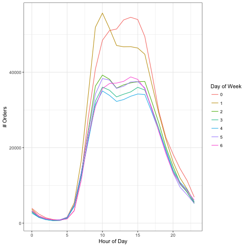

```r
# orders by day of week/hour of day
wkhr_orders = orders %>% group_by(order_dow, order_hour_of_day) %>% summarize(numorders = n())

# Plot of orders by hour of day for each week of day
ggplot(data = wkhr_orders) +
  geom_line(aes(x = order_hour_of_day, y = numorders, color = factor(order_dow))) +
  xlab("Hour of Day") + ylab("# Orders") + scale_color_discrete(name = "Day of Week") +
  theme_bw()
```

It is not clear whether day 0 is Saturday or Sunday. Since the number of orders is higher for days 0 and 1, maybe 0 and 1 are Saturday and Sunday. But certain other analysis further down seem to indicate that 0 is Sunday.

```r
# create a dataset that calculates for each product, the percentage of product orders at each hour of day
ordprd2 = inner_join(ordprd, orders[,c("order_id","order_hour_of_day")], by = "order_id")
ordprd2a = ordprd2 %>% group_by(product_id, order_hour_of_day) %>%
            summarize(numorders = n()) %>% mutate(pctorders = numorders/sum(numorders))
ordprd2a = inner_join(ordprd2a, prod_top80pct[,c("product_id"), drop = FALSE], by = "product_id")
```

Find products with different patterns of purchase timing by hour of day with PCA. Dataset for PCA has for each product (rows), the percentage of product orders at each hour of day (column)

```r
ordprd2a_s = ordprd2a %>% select(-numorders) %>% spread(order_hour_of_day, pctorders, fill = 0)
```

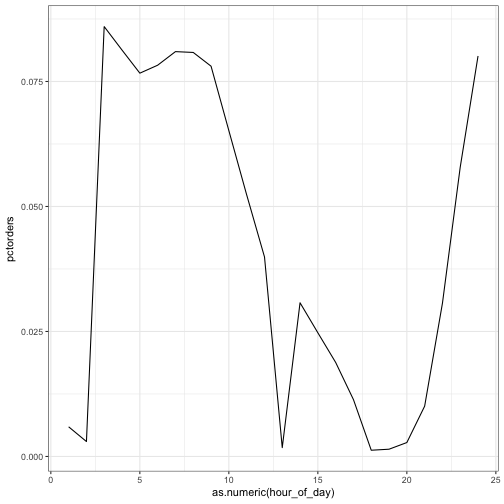

```r
# Plot a row (product_id - 1, chocolate sandwich cookies)
ordprd2a_sample = data.frame(hour_of_day = names(ordprd2a_s)[-1], pctorders = t(ordprd2a_s[ordprd2a_s$product_id == 24852,-1]))
ggplot() + geom_line(data = ordprd2a_sample, aes(x = as.numeric(hour_of_day), y = pctorders)) + theme_bw()
```

Next I will do a PCA on this data. Since all the data is in percentages, I didn't do any further scaling of data

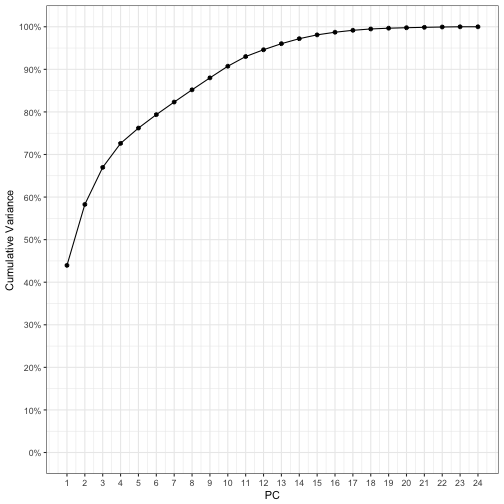

```r
# Perform a PCA (rows - products, variables - hour of day)
pcdata = ordprd2a_s
pc_mdl = prcomp(x = pcdata[,-1], center = TRUE, scale. = FALSE)

# Get the plot of cumulative variance explained by each principal component
pc_mdl_var = cumsum(pc_mdl$sdev^2)/sum(pc_mdl$sdev^2)
pc_mdl_vardf = data.frame(pc = 1:length(pc_mdl_var), cumvar = pc_mdl_var)
p_cumvar = ggplot() +
           geom_line(data = pc_mdl_vardf, aes(x = pc, y = cumvar)) +
           geom_point(data = pc_mdl_vardf, aes(x = pc, y = cumvar)) +
           xlab("PC") + ylab("Cumulative Variance") +
           scale_x_continuous(breaks = 1:length(pc_mdl_var)) +
           scale_y_continuous(labels = percent, breaks = seq(0,1,by=0.1)) + expand_limits(y = 0) +
           theme_bw()
p_cumvar
```

The plot of cumulative variance shows that first component accounts for 44% of variance, first two account for 58% and first 3 account for 67% of variance. Next, we will look at the first two loadings since first 2 components account for 58% of variance.

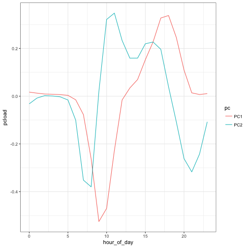

```r
# Get loadings plot for 2 principal components
numcomp = 2

pc_loadings = data.frame(pc_mdl$rotation)
pc_loadings$hour_of_day = seq(0,23)
pc_loadings_g = pc_loadings %>% gather(pc, pcload, -hour_of_day)

pcfilt = paste0("PC",seq(1,numcomp))
pc_loadings_g = pc_loadings_g[pc_loadings_g$pc %in% pcfilt,]

p_pcload = ggplot() + geom_line(data = pc_loadings_g, aes(x = hour_of_day, y = pcload, color = pc)) +
             theme_bw()
p_pcload
```

First principal component loading PC1 indicates a pattern of either higher percentage of purcahses in the morning or evening. The second principal component loading indicates a pattern where there is higher purchase around 11am and 4pm. To check which product items follow these patterns, we look at products that either have high scores or low scores on a principal component. So here we take the top 20 and bottom 20 products in terms of their scores on PC1. The actual pattern still may not quite match the loading plot since the overall pattern is a combination of all principal component loadings.

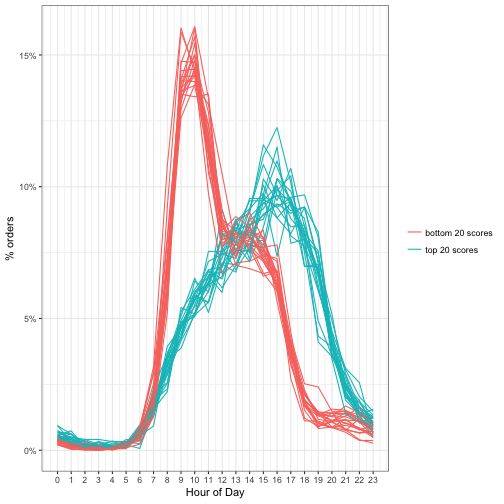

```r
# Scatter plot of PC1 and PC2 scores
pc_scores = data.frame(pc_mdl$x)
pc_scores$product_id = pcdata$product_id
pc_scores = inner_join(pc_scores, prods[,c("product_id", "product_name")], by = "product_id")

# sort products based on PC1 scores
pc_scores_pick = pc_scores %>% arrange(desc(PC1))

# get top and bottom 20 products based on the scores
prod_top20 = pc_scores_pick$product_name[1:20]
prod_bot20 = pc_scores_pick$product_name[(nrow(pc_scores_pick) - 19):nrow(pc_scores_pick)]

# plot hourly purchase profile for a list of products that are in top and bottom 20 scores of PC1
prodlist_topbot20 = data.frame(top_scores = prod_top20, bottom_scores = prod_bot20)
prodlist = c(prod_top20, rev(prod_bot20))
prodlist_label = c(rep("top 20 scores", 20), rep("bottom 20 scores", 20))
scoreid = c(seq(1,20), seq(1,20))
prodlistdf = data.frame(product_name = prodlist, prodlist_label, scoreid, stringsAsFactors = FALSE)
prodlistdf = inner_join(prodlistdf, prods[, c("product_id", "product_name")], by = "product_name")

prodlist_profile = inner_join(ordprd2a_s, prodlistdf[, c("product_id", "product_name", "prodlist_label")], by = "product_id")

prodlist_profile_g = prodlist_profile %>% gather(hour_of_day, pctorders, -product_name, -product_id, -prodlist_label)

ggplot() +
  geom_line(data = prodlist_profile_g, aes(x = as.numeric(hour_of_day), y = pctorders,
                                           group = product_name, color = prodlist_label)) +
         xlab("Hour of Day") + ylab("% orders") +
         scale_x_continuous(breaks = seq(0,23)) + scale_y_continuous(labels = percent) +
         theme_bw() + theme(legend.title = element_blank())
```

Below is the table that lists the actual products that are in top and bottom scores of PC1. Ice cream purchases tend to occur more in the evening. Items like granola bars, krispie treats, apples are purchased more in the morning.

```r
prodlist_topbot20
```

```
##                                                        top_scores
## 1                                   Salted Caramel Core Ice Cream
## 2                               Chocolate Fudge Brownie Ice Cream
## 3                                    The Tonight Dough™ Ice Cream
## 4     Cashew Milk Salted Caramel Cluster Non-Dairy Frozen Dessert
## 5                   Ice Cream, Super Premium, Mint Chocolate Chip
## 6                                 Raspberry Chocolate Chip Gelato
## 7  Coconut Milk Non Dairy Frozen Dessert No Sugar Added Mint Chip
## 8                               Organic Cookies & Cream Ice Cream
## 9                                           Half Baked® Ice Cream
## 10                                       Half Baked Frozen Yogurt
## 11                             Chocolate Chocolate Chip Ice Cream
## 12                          New York Super Fudge Chunk® Ice Cream
## 13                                         Butter Pecan Ice Cream
## 14                       Vanilla, Chocolate, Strawberry Ice Cream
```

[output cut: 27 more lines]

## PCA to find patterns of purchase by day of week

Dataset for PCA has for each product (rows), the percentage of product orders at each day of week (column)

```r
ordprd3 = inner_join(ordprd, orders[, c("order_id", "order_dow")], by = "order_id")

ordprd3a = ordprd3 %>% group_by(product_id, order_dow) %>%
  summarize(numorders = n()) %>% mutate(pctorders = numorders/sum(numorders))
ordprd3a = inner_join(ordprd3a, prod_top80pct[,c("product_id"), drop = FALSE], by = "product_id")
```

The different analysis for PCA done for the case of purchase by hour of day have been wrapped into 3 functions that are defined in `pca_funs.R` (code)[pca_funs.R]

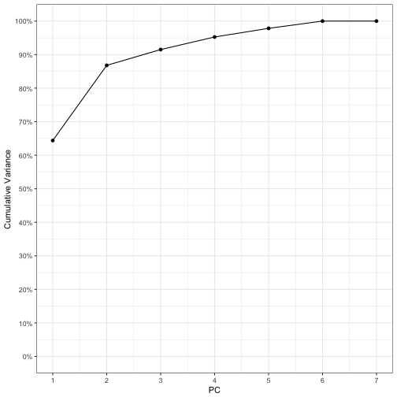

```r
ordprd3a_s = ordprd3a %>% select(-numorders) %>% spread(order_dow, pctorders, fill = 0)

# perform PCA and plot cumulative variance
pcmdl_dow = getpca(pcdata = ordprd3a_s)
pcmdl_dow$p_cumvar
```

In this case, the first two principal components account for ~90% of variance. The loadings for first two components are plotted next.

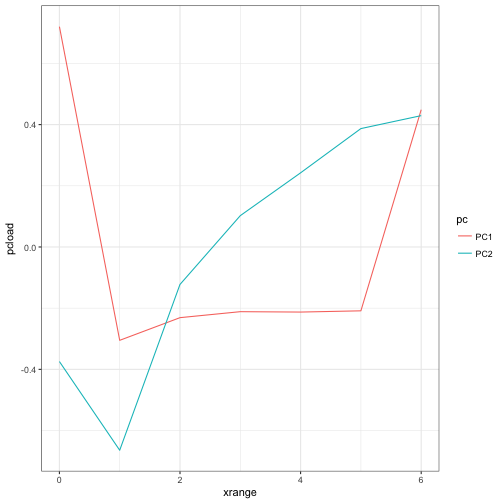

```r
pcplots_dow = get_pcaplots(pcmdl_dow, numcomp = 2, ordprd3a_s, ordprd3a_s, prods, seq(0,6), "day of week")
pcplots_dow$p_pcload
```

The products with high scores on first component would tend to be purchased more at the ends of the week and products with low scores on first component would tend to be purchased less at the ends of the week. The plot of products having top and bottom 20 scores on PC1 is shown next.

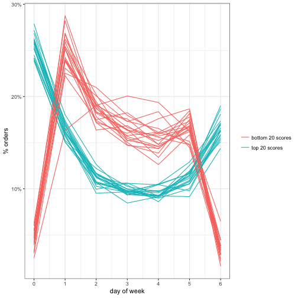

```r
pcplots_dow$p_items[[1]]
```

The table below shows the names of products with top and bottom 20 scores on PC1. It looks like cookies and chocolates are bought less in weekends compared to cooking items.

```r
pcplots_dow$prodlist_topbot20[[1]]
```

```
##                                     top_scores
## 1                   Black Beans Reduced Sodium
## 2  99% Fat Free Natural Goodness Chicken Broth
## 3                      Mild Diced Green Chiles
## 4                         90% Lean Ground Beef
## 5                     Organic Brussels Sprouts
## 6                         Jumbo Lump Crab Cake
## 7         Organic No Salt Added Diced Tomatoes
## 8                             Spaghetti Squash
## 9                    Boneless Beef Chuck Roast
## 10                   Tikka Masala Simmer Sauce
## 11                         Golden Sweet Potato
## 12                   No Salt Added Black Beans
## 13                              Poblano Pepper
## 14                 Crushed Tomatoes With Basil
```

[output cut: 27 more lines]

The products with high scores on second component would tend to be purchased more at the end of the week and products with low scores on first component would tend to be purchased more at the beginning of the week. The plot of products having top and bottom 20 scores on PC2 is shown next.

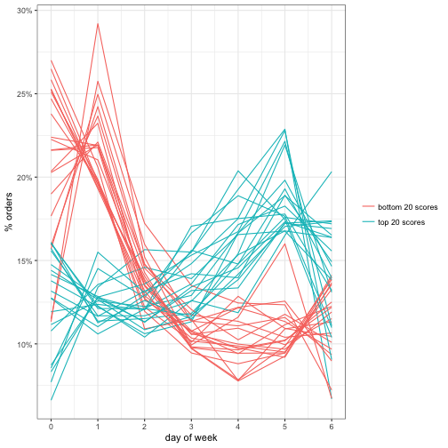

```r
pcplots_dow$p_items[[2]]
```

Looks like some wine and vodka is purchased more as the week progresses.

```r
pcplots_dow$prodlist_topbot20[[2]]
```

```
##                                     top_scores
## 1            Handmade Vodka From Austin, Texas
## 2                   Little Sumpin' Sumpin' Ale
## 3                                          IPA
## 4                               Handmade Vodka
## 5                                 Humboldt Fog
## 6                      Belgian White Wheat Ale
## 7                      Prosecco Sparkling Wine
## 8                              Lemon-Lime Soda
## 9                             Vanilla Cupcakes
## 10                                   Camembert
## 11                               Challah Bread
## 12                   Hash Browns Country Style
## 13                            Tostitos  Scoops
## 14 Pure Cane Confectioners 10-X Powdered Sugar
```

[output cut: 27 more lines]

## PCA to find patterns of purchase by days since prior order

Dataset for PCA has for each product (rows), the percentage of product orders at each of days since prior order (column)

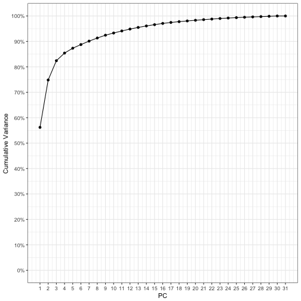

```r
ordprd4 = inner_join(ordprd, orders[!is.na(orders$days_since_prior_order), c("order_id", "days_since_prior_order")], by = "order_id")

ordprd4a = ordprd4 %>% group_by(product_id, days_since_prior_order) %>%
  summarize(numorders = n()) %>% mutate(pctorders = numorders/sum(numorders))
ordprd4a = inner_join(ordprd4a, prod_top80pct[,c("product_id"), drop = FALSE], by = "product_id")

# PCA of purchase timing (days since prior order)

ordprd4a_s = ordprd4a %>% select(-numorders) %>% spread(days_since_prior_order, pctorders, fill = 0)

# Do a PCA
pcmdl_prior = getpca(pcdata = ordprd4a_s)
pcmdl_prior$p_cumvar
```

First two principal components account for 75% of variance. The loadings for the first two components is shown next.

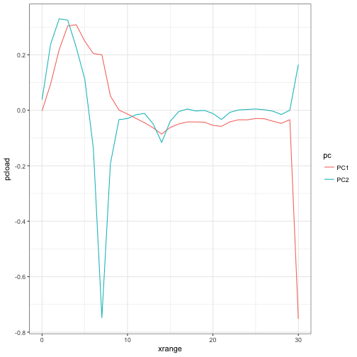

```r
pcplots_prior = get_pcaplots(pcmdl_prior, numcomp = 2, ordprd4a_s, ordprd4a_s, prods, seq(0, 30), "days since prior order")
pcplots_prior$p_pcload
```

Products with high scores in first principal component will tend to be purchased more in orders that are less than a week from previous order and products with low scores on the first principal component will tend to be purchased in orders that are more than a month after the previous order

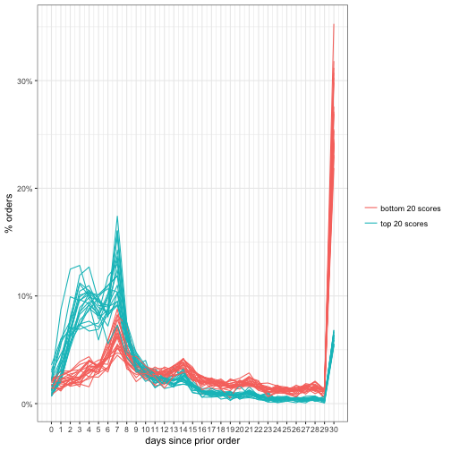

```r
pcplots_prior$p_items[[1]]
```

Items like trash bag, laundary detergents, towels are in orders that are made less often (longer than once per month) whereas the food/drink related items are in orders that are made more frequently (less than a week)

```r
pcplots_prior$prodlist_topbot20[[1]]
```

```
##                                                                      top_scores
## 1                                                          Ultra-Purified Water
## 2                                                 Grass milk Raw Cheddar Cheese
## 3                                White with 30% Cacao Content Organic Chocolate
## 4                         Baby Food Pouch - Butternut Squash, Carrot & Chickpea
## 5                                          Organics Big Bird's Apple 100% Juice
## 6  Stage 1 Apples Sweet Potatoes Pumpkin & Blueberries Organic Pureed Baby Food
## 7                                                           Organic  Whole Milk
## 8                                                    Whole Organic Omega 3 Milk
## 9                                                   Just Sweet Potato Baby Food
## 10                                               Organic Homogenized Whole Milk
## 11                                                              Honeydew Chunks
## 12                                                      100% Whole Wheat Bagels
## 13                                              Half And Half Ultra Pasteurized
## 14                                Organic Stage 2 Winter Squash Baby Food Puree
```

[output cut: 27 more lines]

Products with high scores in principal component 2 will tend to have higher percentage of orders with days since previous order of less than a week and products with low scores in principal component 2 will tend to have a higher percentage of orders that are weekly in frequency.

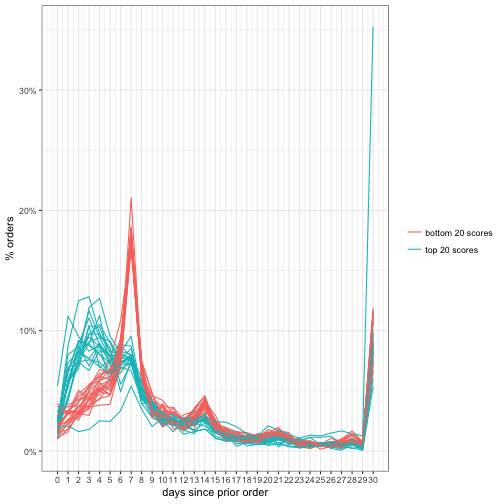

```r
pcplots_prior$p_items[[2]]
```

Juices, milk and wine tend to be in orders who frequency is less than a week. Items like Greek Yogurt, Apples and Granola bar are in orders who frequency is weekly.

```r
pcplots_prior$prodlist_topbot20[[2]]
```

```
##                                        top_scores
## 1                            Ultra-Purified Water
## 2                                             Ice
## 3                                           Vodka
## 4    Organic European Style Sweet Unsalted Butter
## 5                       80  Vodka Holiday Edition
## 6                                 Chardonnay Wine
## 7  Organic Coconut Bliss Vanilla Island Ice Cream
## 8                  Natural Artesian Bottled Water
## 9                                      Chardonnay
## 10                  Grass milk Raw Cheddar Cheese
## 11              Handmade Vodka From Austin, Texas
## 12                         Lemon Love Juice Drink
## 13         Pure Cane Confectioners Powdered Sugar
## 14                              Premium Ice Cubes
```

[output cut: 27 more lines]